# Allosteric Cooperativity in Tetramer Mixture

## Posits

1. We consider a mixture of two components A (active) and I (inactive).
2. The components form exclusively tetramers.
3. The composition of tetramers is purely stochastic.
4. The mixture is defined by the ratio of the concentrations of A and I.

## Configurations

We have 5 possible configurations, not counting any permutations: AAAA, AAAI, AAII, AIII, IIII

## Nomenclature

- concentration a = c(A)
- concentration i = c(I)
- concentration ratio *r*; *[eq1]*

```r
r = a / i
```

- total concentration *C*; *[eq2]*

```r
C = a + i
```

## Concentrations

### Concentration in terms of *r*; *[eq3]*

```r
r = 10; # in practice (below) a sequence from 0 to 10
a = r * i;
i = a / r;
```

### Concentration *a*; *[eq4]* in *[eq2]*

```r
a + (a / r) = C;
a (1 + (1 / r)) = C;
a = C / (1 + (1 / r));
```

### Concentration *i*; *[eq3]* in *[eq2]*

```r
r * i + i = C;
i (1 + r) = C;
i = C / (1 + r);
```

## Constants: Total concentration and allosteric coefficient

```r
C = 1;
AC = 2;
```

## Models for enzymatic activities of tetramers

1. Non-cooperative (linear) model

```r
aaaa_ea = aaai_ea = aaii_ea = aiii_ea = iiii_ea = 1;
```

```r
aaaa_ea = (4/4)^AC;
aaai_ea = (3/4)^AC;
aaii_ea = (2/4)^AC;
aiii_ea = (1/4);
iiii_ea = (0/4);
```

## Evaluate enzymatic activity (ea) of the tetramer mixture for a range of A/I concentration ratios

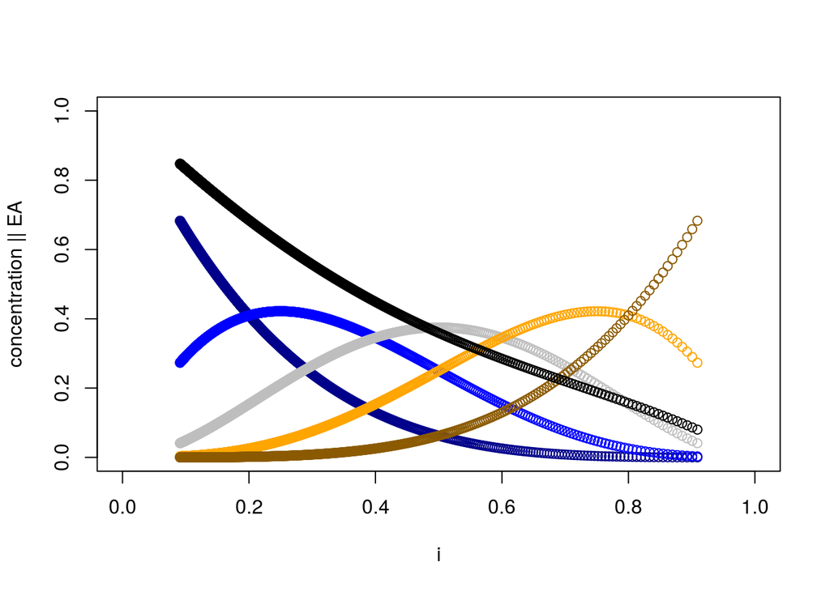

```r
rs = seq(0.1, 10, by = 0.01);

eval.ea = lapply(rs, function(r) {
    a = C / (1 + 1 / r);
    i = C / (1 + r);
    sum(a + i);

    #_______________________________________________________________________________
    ## tetramer concentrations
    aaaa = a^4;
    aaai = 4 * a^3 * i;
    aaii = 6 * a^2 * i^2;
    aiii = 4 * a * i^3;
    iiii = i^4;
    stopifnot(isTRUE(all.equal(sum(aaaa + aaai + aaii + aiii + iiii), 1)));

    #_______________________________________________________________________________
    ## total enzymatic activity of tetramer mixture
    total_ea =  aaaa * aaaa_ea +
                aaai * aaai_ea +
                aaii * aaii_ea +
                aiii * aiii_ea +
                iiii * iiii_ea;

    c(i, aaaa, aaai, aaii, aiii, iiii, total_ea);
});

eval.ea.df = do.call(rbind.data.frame, eval.ea);
colnames(eval.ea.df) = c("i", "aaaa", "aaai", "aaii", "aiii", "iiii", "total_ea");
plot(abs(eval.ea.df[ ,1]), eval.ea.df[ ,2], col = "blue4",
            xlim = c(0, 1), ylim = c(0, 1),
            xlab = c("i"), ylab = ("concentration || EA"));
points(abs(eval.ea.df[ ,1]), eval.ea.df[ ,3], col = "blue1");
points(abs(eval.ea.df[ ,1]), eval.ea.df[ ,4], col = "grey");
points(abs(eval.ea.df[ ,1]), eval.ea.df[ ,5], col = "orange1");
points(abs(eval.ea.df[ ,1]), eval.ea.df[ ,6], col = "orange4");
points(abs(eval.ea.df[ ,1]), eval.ea.df[ ,7], col = "black");
```

## Linear regression

### Experimental Input data

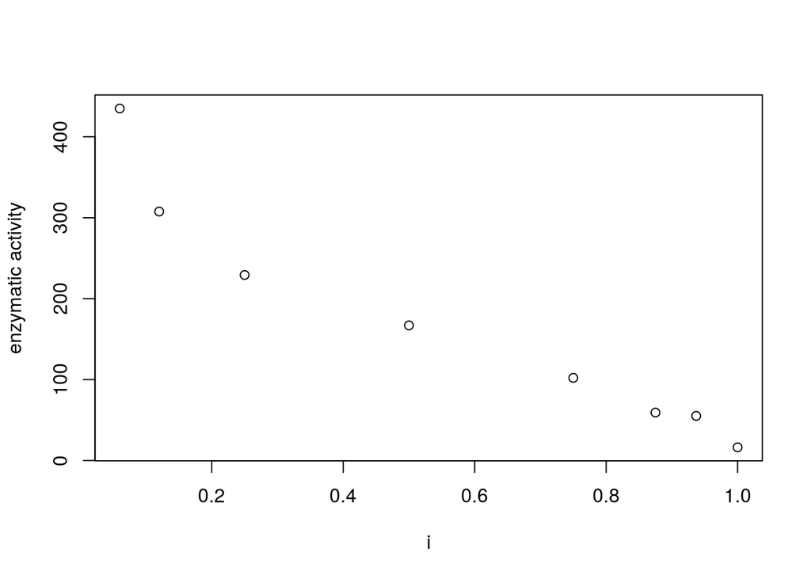

```r
dat = read.table("processed_kinetic_data.tsv", header = TRUE);
plot(abs(dat[ , "c_mutant"]), dat[ , "pep0.6_1_fbp"], xlab = c("i"), ylab = c("enzymatic activity"));
```

### Linear regression model

The non-linearity in the model originates from the cooperativity exponent, a type of Hill coefficient. In contrast to allosteric models, we do not model binding events, merely the composition of the tetramers changes with increasing amount on inactive monomer. The non-linearity of the enzymatic activity can be modelled via an exponent (like a Hill coefficient). However, for linear regression we need an equation that is linear in the fit parameters. The solution is a log expression of the enzymatic activity (EA). The factors [4,3,2,1] inside the log function are the number of active monomers, which modulate the tetramer concentrations to the concentration of active monomers.

```r
log(EA) = AC * log(4 * aaaa) + AC * log(3 * aaai) + AC * log(2 * aaii) + AC * log(1 * aiii);
```

### Linear regression

#### Compute concentrations of tetramers

```r
## c_wildtype
dat = cbind(dat, (1 - dat[ ,1]));
colnames(dat) = c(colnames(dat)[-length(colnames(dat))], "c_wt");
## aaaa
dat = cbind(dat, dat[ , "c_wt"]^4);
colnames(dat) = c(colnames(dat)[-length(colnames(dat))], "aaaa");
## aaai
dat = cbind(dat, 4 * dat[ , "c_wt"]^3 * dat[ , "c_mutant"]^1);
colnames(dat) = c(colnames(dat)[-length(colnames(dat))], "aaai");
## aaii
dat = cbind(dat, 6 * dat[ , "c_wt"]^2 * dat[ , "c_mutant"]^2);
colnames(dat) = c(colnames(dat)[-length(colnames(dat))], "aaii");
## aiii
dat = cbind(dat, 4 * dat[ , "c_wt"]^1 * dat[ , "c_mutant"]^3);
colnames(dat) = c(colnames(dat)[-length(colnames(dat))], "aiii");
## iiii
dat = cbind(dat, dat[ , "c_mutant"]^4);
colnames(dat) = c(colnames(dat)[-length(colnames(dat))], "iiii");
### sum
dat = cbind(dat, apply(dat[ , c("aaaa","aaai","aaii","aiii","iiii")], 1, sum));
colnames(dat) = c(colnames(dat)[-length(colnames(dat))], "C");
```

### plot log of enzymatic activity over log of (scaled) concentration of active units

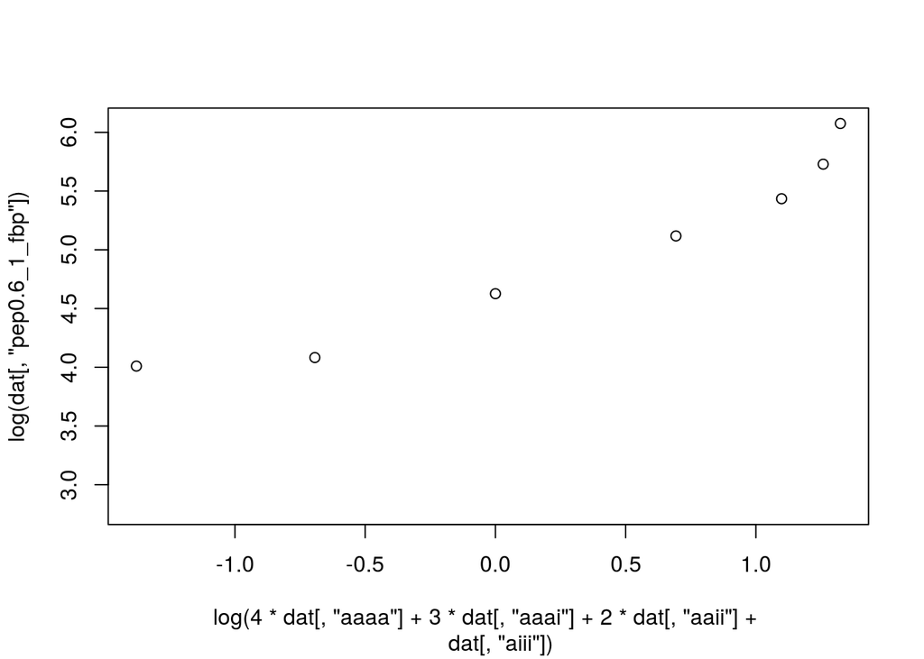

```r
plot(log(4*dat[, "aaaa"] + 3*dat[, "aaai"] + 2*dat[, "aaii"] + dat[, "aiii"]), log(dat[, "pep0.6_1_fbp"]));
```

```r
#myLm = lm(log(dat[ ,15]) ~ log(4 * dat[ , "aaaa"]) + log(3 * dat[ , "aaai"]) + log(2 * dat[ , "aaii"]) + log(1 * dat[ , "aiii"]));
myLm = lm(dat[ , "pep0.6_1_fbp"] ~ dat[ , "aaaa"]);
```